# JELSCH BOND 2_0_0.15_10_Density

11/67

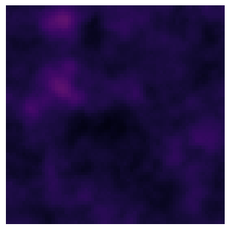

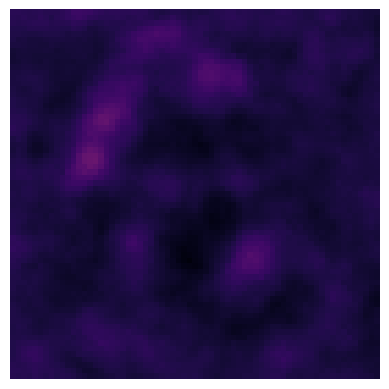

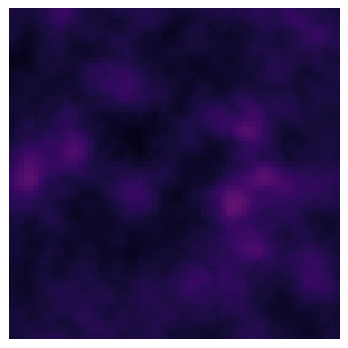

12/67

12/67

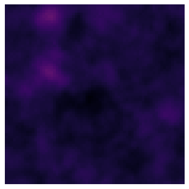

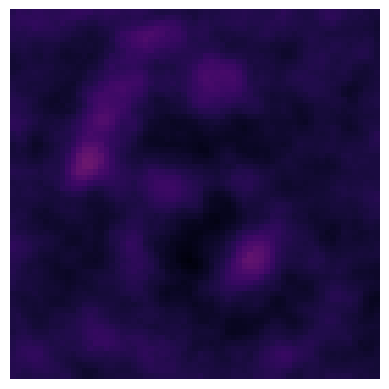

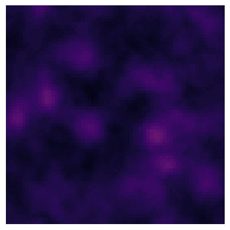

13/67

13/67

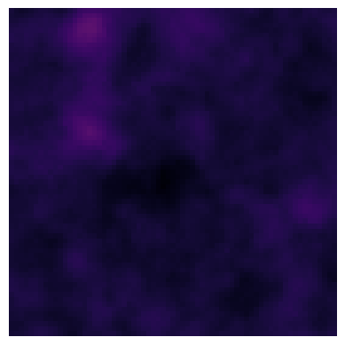

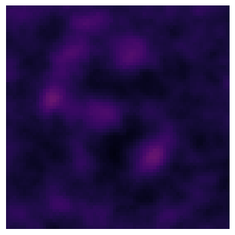

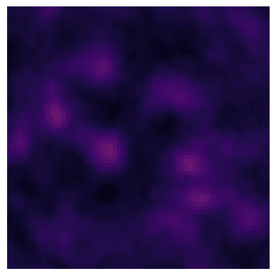

14/67

14/67

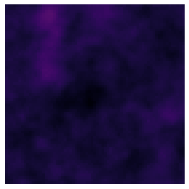

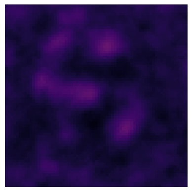

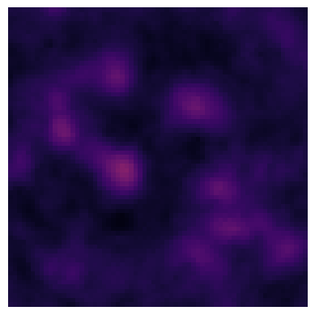

15/67

15/67

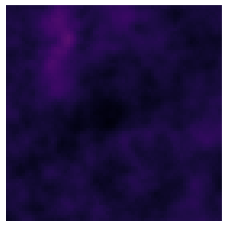

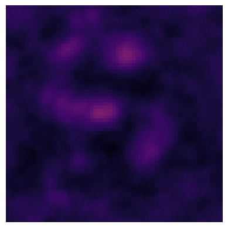

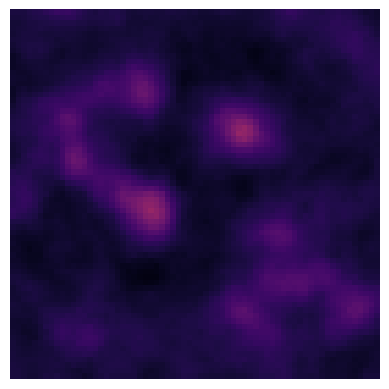

16/67

16/67

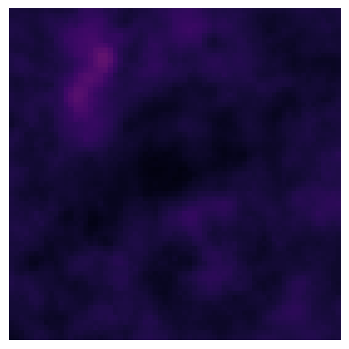

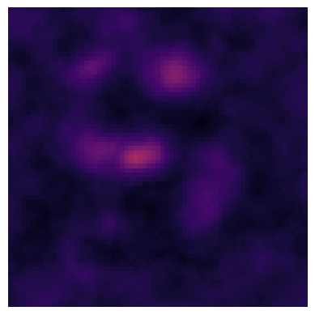

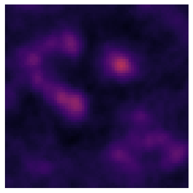

17/67

17/67

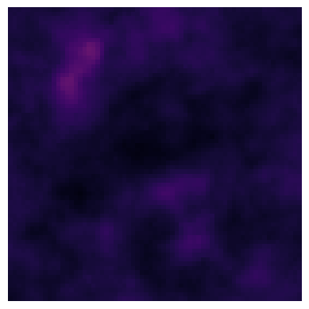

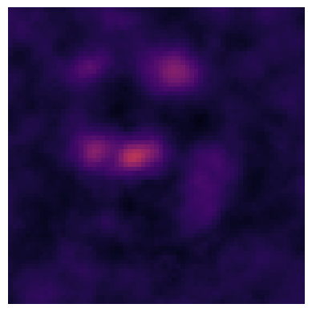

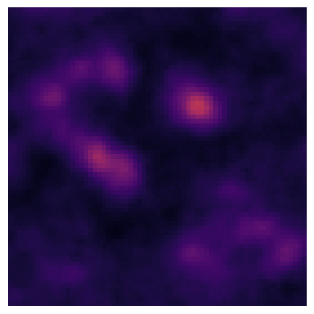

18/67

18/67

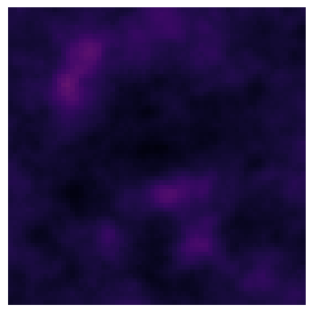

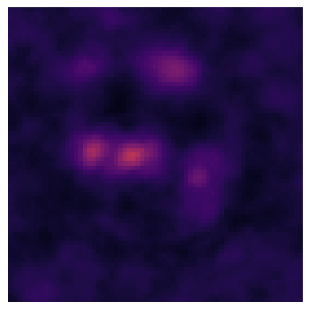

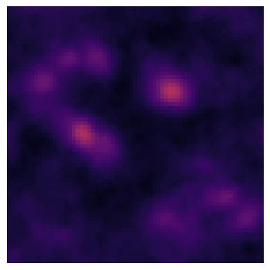

19/67

19/67

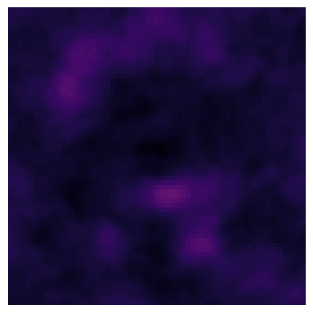

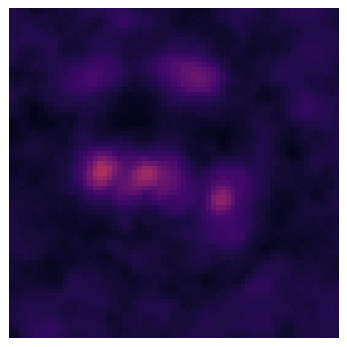

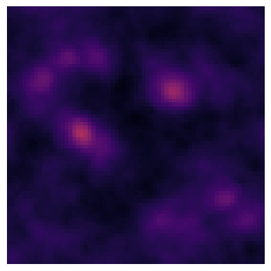

20/67

20/67

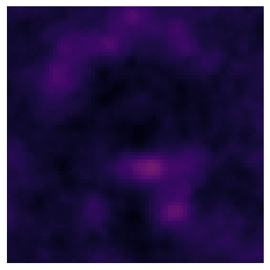

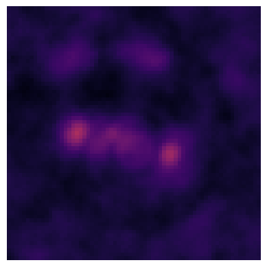

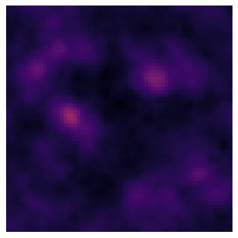

21/67

21/67

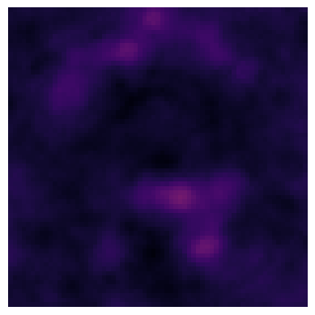

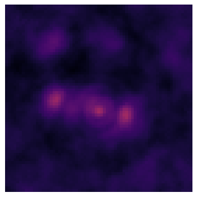

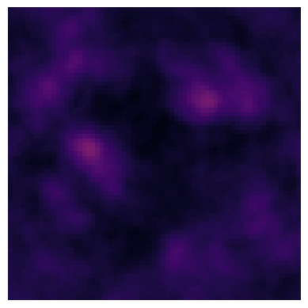

22/67

22/67

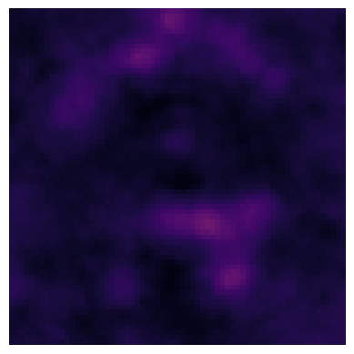

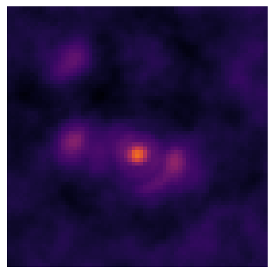

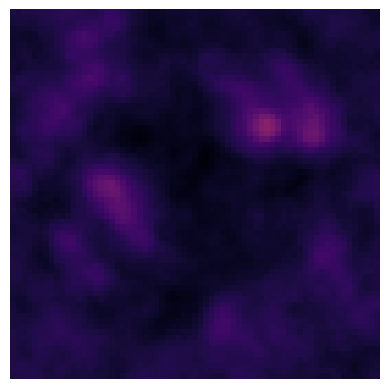

23/67

23/67

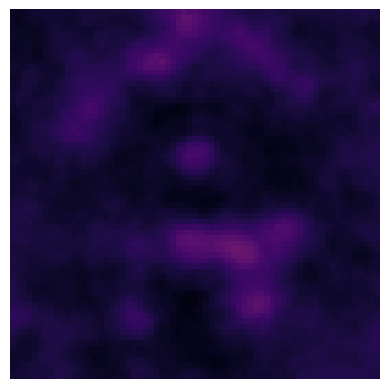

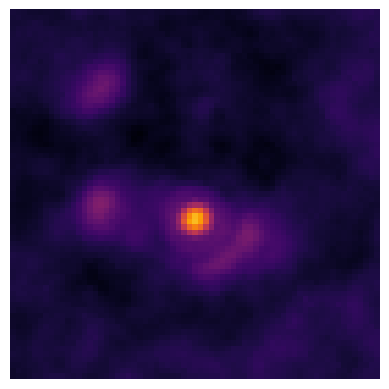

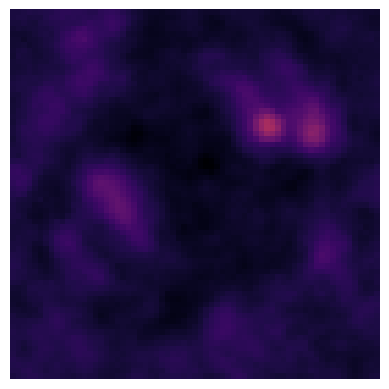

24/67

24/67

24/67

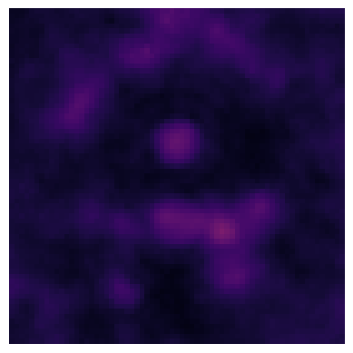

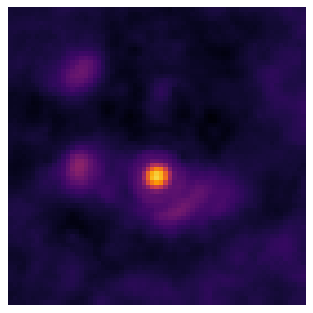

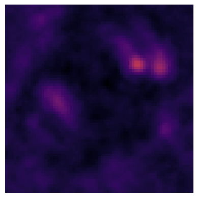

25/67

25/67

25/67

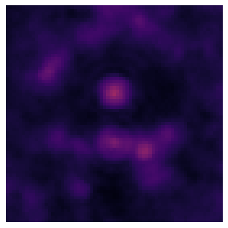

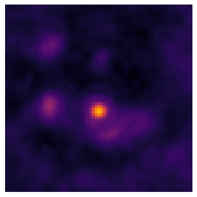

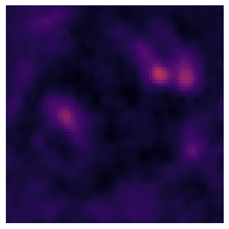

26/67

26/67

26/67

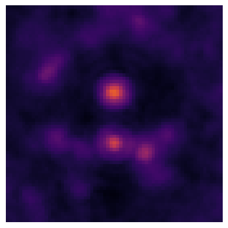

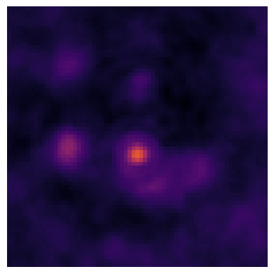

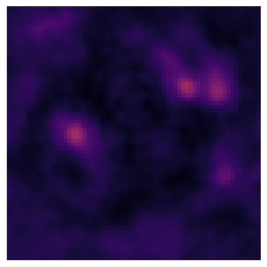

27/67

27/67

27/67

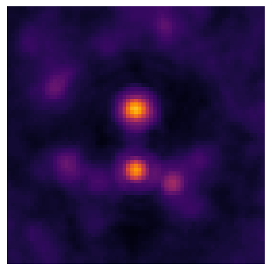

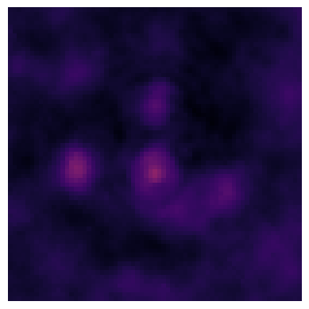

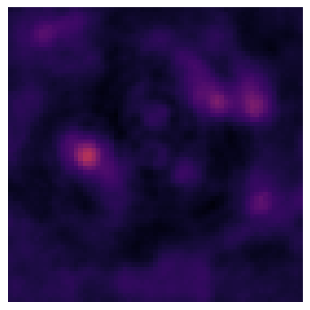

28/67

28/67

28/67

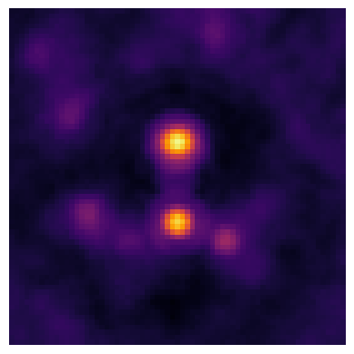

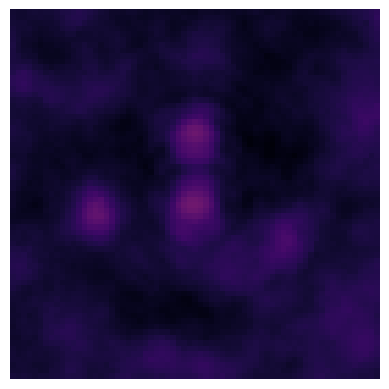

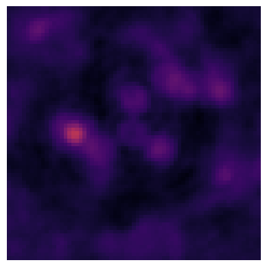

29/67

29/67

29/67

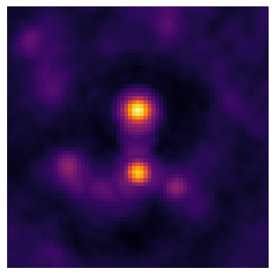

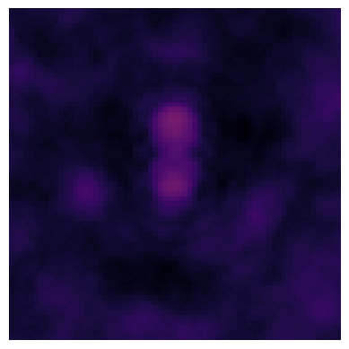

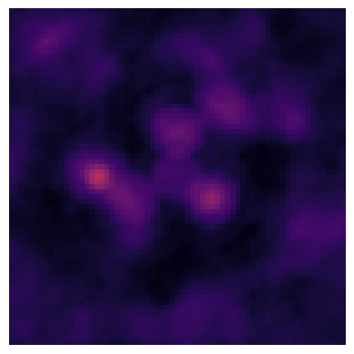

30/67

30/67

30/67

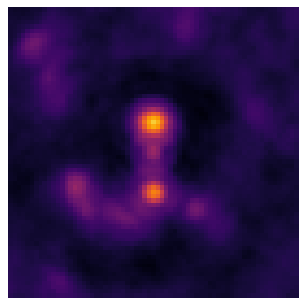

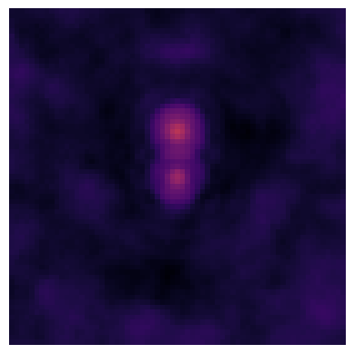

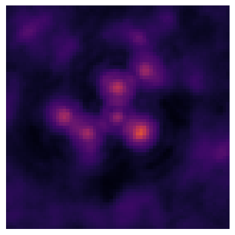

31/67

31/67